# Nintendo Games Midpoint Deliverable

Jared Lim, Brian Ho, Asigiah, Harlette Tanduyan

11/30/2020

# Introduction

This is the midpoint deliverable on our final project, which is about analyzing video game sales published by Nintendo. The source of the data can be found [here](https://www.kaggle.com/ashaheedq/video-games-sales-2019). The overall purpose of this project is to get a better understanding of where Nintendo’s revenue comes from. The other purpose is to understand the overall revenue and popularity of Nintendo’s most well-known video game titles.

## Aggregated Data Summary

The table below shows an aggregated table of information.

| Rank | Name | Genre | ESRB Rating | Platform | Critic Score | User Score | Total Copies Shipped (in millions) | Year Released |
| --- | --- | --- | --- | --- | --- | --- | --- | --- |
| 1 | Wii Sports | Sports | E | Wii | 7.7 | NA | 82.86 | 2006 |
| 2 | Super Mario Bros. | Platform |  | NES | 10.0 | NA | 40.24 | 1985 |
| 3 | Mario Kart Wii | Racing | E | Wii | 8.2 | 9.1 | 37.14 | 2008 |
| 5 | Wii Sports Resort | Sports | E | Wii | 8.0 | 8.8 | 33.09 | 2009 |
| 6 | Pokemon Red / Green / Blue Version | Role-Playing | E | GB | 9.4 | NA | 31.38 | 1998 |
| 7 | New Super Mario Bros. | Platform | E | DS | 9.1 | 8.1 | 30.80 | 2006 |

## Bar Graph of Average Sales Sold By Region

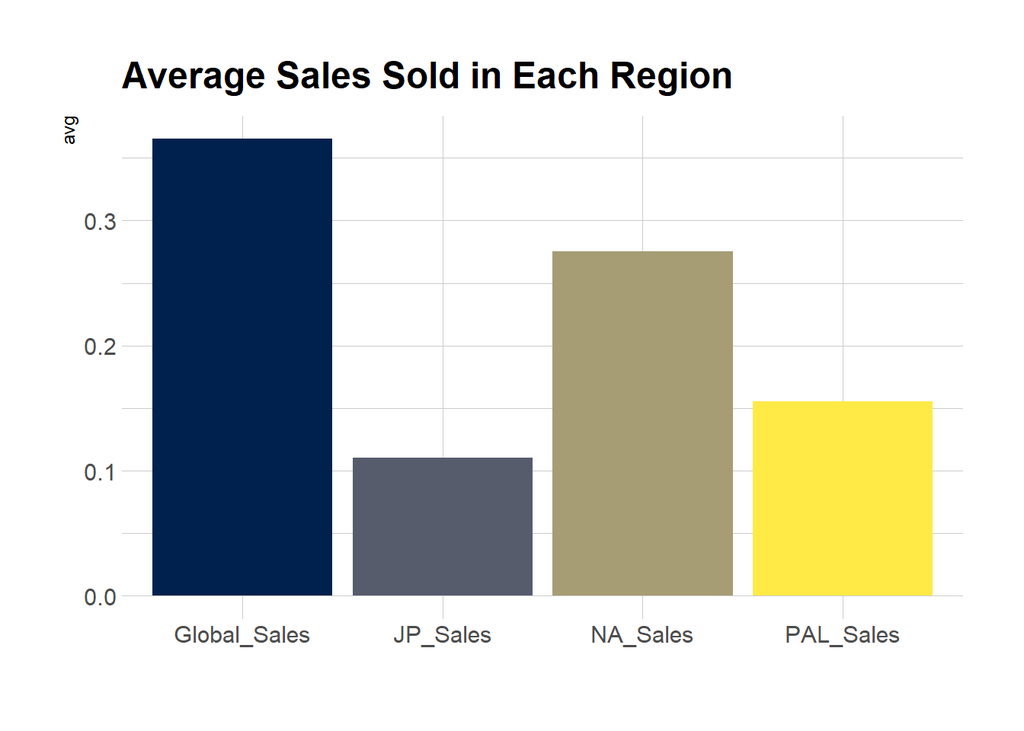

When exploring questions, the chart above helped me specifically answer the question I had in mind. This question consisted of asking,“Which region had the highest number of sales sold?”. The chart did this by ranking the regions with the highest sales sold in millions. The key in reading this chart is being able to absorb the meaning of each information within the different heights of the bars. The higher the bars in each region, means the larger amount of sales of games that were sold. The chart is specifically a bar chart, which allows for easy relative comparison of the different regions, with the height of each making size differences easier to observe.

This chart also reveals key insights. When observing the map, it shows that a large fraction of the global sales are from North America, as North America’s values are the closest to the values of Global Sales. To add on, the chart shows that the PAL and Japan Sales are quite lower in sales sold, than compared to North America. With the vast of information being seen from comparing just regions to global sales overall, it can create the idea that there might be significant difference that may be impacted by a multitude of factors, especially social ones, that are not investigated in this report.

## Nintendo Line Graph

[interactive chart not shown]

This line graph shows the total amount of Nintendo Global sales, Japan sales and North America sales over the years. The x-axis represents the years, from 1975 to 2020. The y-axis represents the value in thousands for amount of sales. This graph helps us understand which region had the most sales each year and how much total sales Nintendo made globally each year.

## Nintedo Dot Plot

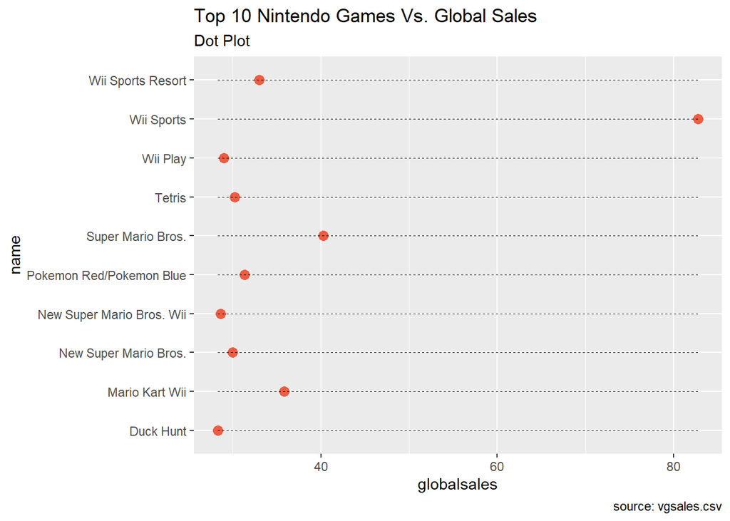

This dot plots hopes to achieve clarity in the leading Nintendo games of the video game industry. One of the most common discussions in the community are which games can be credited to be the best. While that conclusion is entirely subjective, we can approach it through an economical lens to decide how well a game sold throughout the world. Here, the plot displays the current top ten franchises manufactured by Nintendo, as seen on the Y axis, and how many copies in millions sold, as seen on the X axis.

By quick glance, readers can see that in terms of monopoly, *Wii Sports* leads twice as much as its runner up, *Super Mario Bros.* at more than 80 million copies sold worldwide.